# Econ 4

Gracie White

6/2/2019

The data contain estimates of the marginal cost of carbon abatement for four economic sectors (sectors A, B, C, and D). A few notes:  Current carbon emissions in the sectors are: (A=180, B=200, C=220, and D=300).  Sectors A, B, and C are in country X. Sector D is in a different country, Y.  Prices are in $/ton and quantities are in tons.

### 1.

Write down a plausible functional form for the marginal cost of abatement for sector A. Use regression analysis to estimate the parameters of that function. Repeating this for sectors B, C, and D will give you a model of the marginal cost of abatement function for each sector. How well do your models fit the data for each sector? You may need to experiment with different functional forms. Produce a plot of the estimated marginal abatement cost functions in all four sectors (this plot should go in your memo).

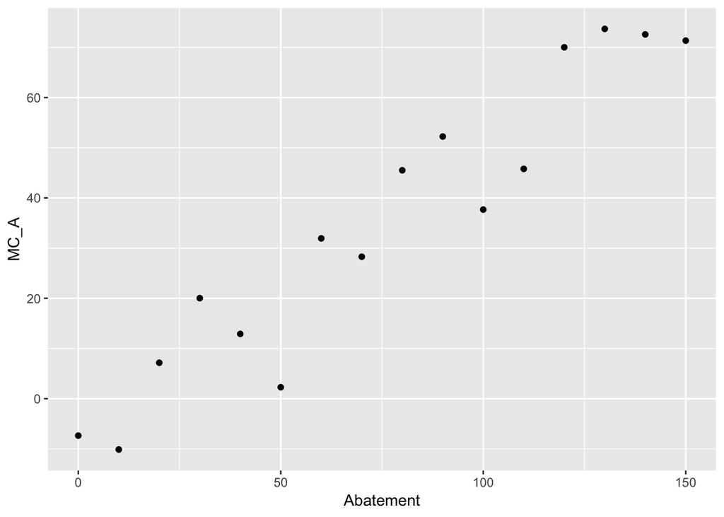

[output not shown]

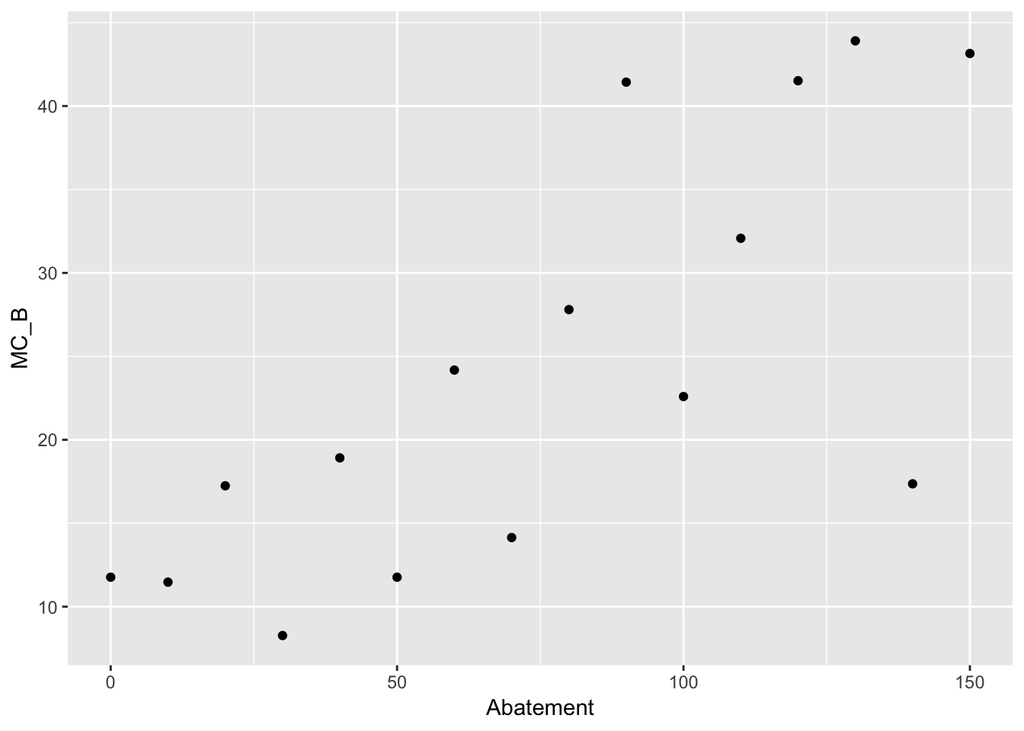

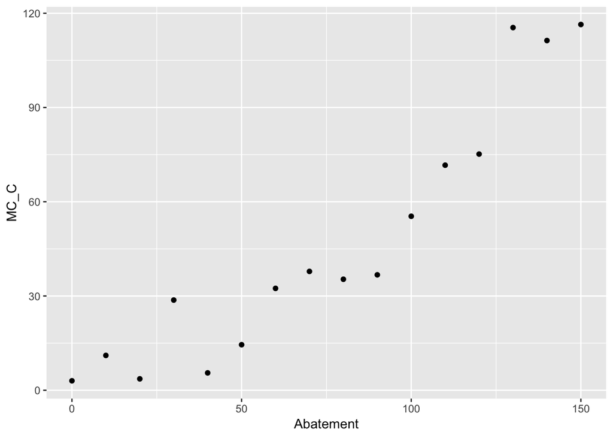

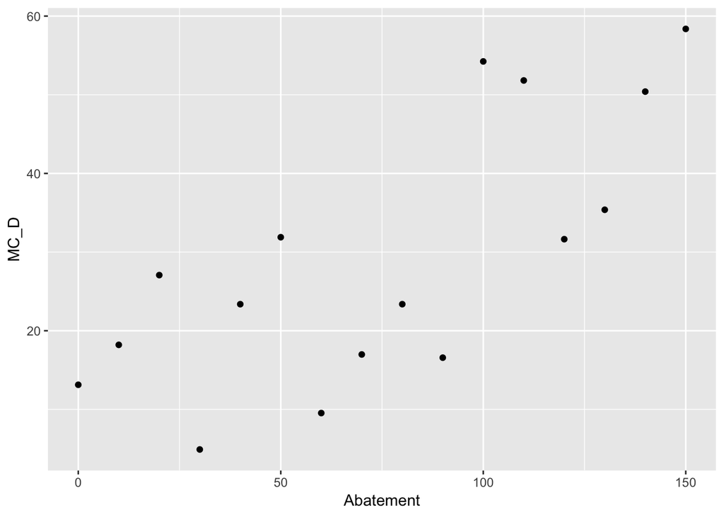

$Marginal~Cost~Abatement~Sector~A = 0.5768419*q + -8.6444767$ $Marginal~Cost~Abatement~Sector~B = 0.1987443*q + 9.3176977$ $Marginal~Cost~Abatement~Sector~C = 0.7838266*q + -11.6550307$ $Marginal~Cost~Abatement~Sector~D = 0.2599275*q + 9.6875061$

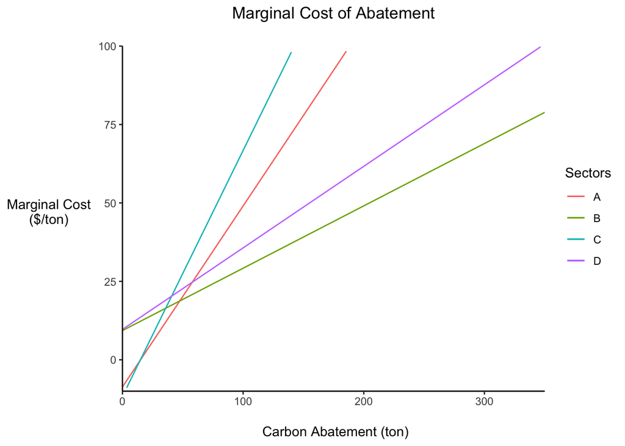

### 2.

Using these models and the current level of carbon emissions, derive each sector’s demand curve for carbon emissions. In other words, how much would each sector be willing to pay for the right to pollute the first unit, second unit, etc? Draw these demand curves on a graph. Which sector is willing to pay the most for the first unit of carbon emissions?

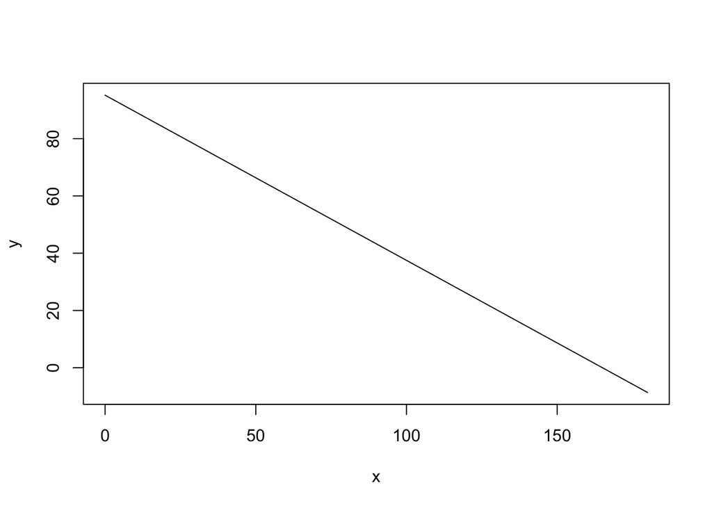

```r
#Sector A - Current Emissions = 180

quant_a <- seq(0,180,by=10)
curve_d_a <- function(q){
  (slope_a*(180-q)) + int_a
}
demand_a <- curve_d_a(quant_a)
curve(curve_d_a, from=0, to=180, xlab = "x", ylab = "y") #looks like it worked. Sweet.
```

```r
demand_a
```

```
##  [1] 95.187063 89.418644 83.650225 77.881806 72.113387 66.344969 60.576550
##  [8] 54.808131 49.039712 43.271293 37.502874 31.734455 25.966037 20.197618
## [15] 14.429199  8.660780  2.892361 -2.876058 -8.644477
```

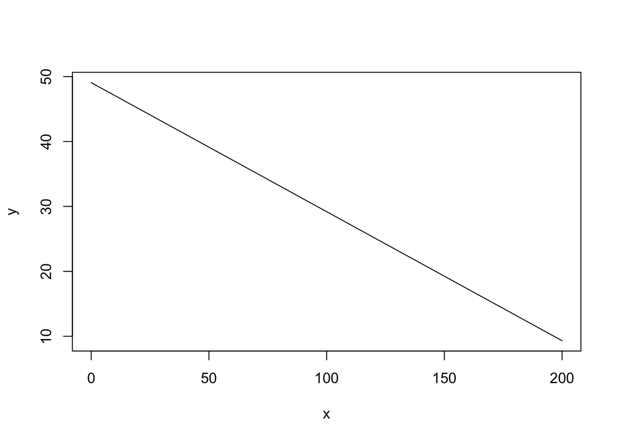

```r
#Sector B - Current Emissions = 200
quant_b <- seq(0,200,by=10)
curve_d_b <- function(q){
  (slope_b*(200-q)) + int_b
}
demand_b <- curve_d_b(quant_b)
curve(curve_d_b, from=0, to=200, xlab = "x", ylab = "y") #looks like it worked. Sweet.
```

```r
demand_b
```

```
##  [1] 49.066558 47.079115 45.091672 43.104229 41.116786 39.129343 37.141900
##  [8] 35.154457 33.167014 31.179571 29.192128 27.204685 25.217242 23.229799
## [15] 21.242356 19.254913 17.267470 15.280027 13.292584 11.305141  9.317698
```

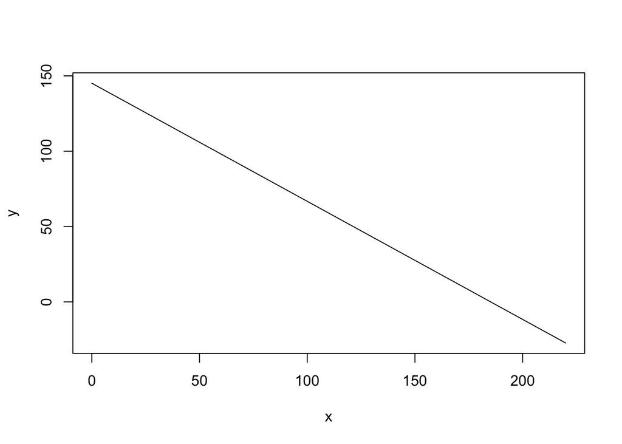

```r
#Sector C - Current Emissions = 220

quant_c <- seq(0,220,by=10)
curve_d_c <- function(q){
  (slope_c*(200-q)) + int_c
}
demand_c <- curve_d_c(quant_c)
curve(curve_d_c, from=0, to=220, xlab = "x", ylab = "y") #looks like it worked. Sweet.
```

```r
demand_c
```

```
##  [1] 145.110286 137.272020 129.433754 121.595489 113.757223 105.918957
##  [7]  98.080691  90.242425  82.404159  74.565894  66.727628  58.889362
## [13]  51.051096  43.212830  35.374564  27.536299  19.698033  11.859767
## [19]   4.021501  -3.816765 -11.655031 -19.493297 -27.331562
```

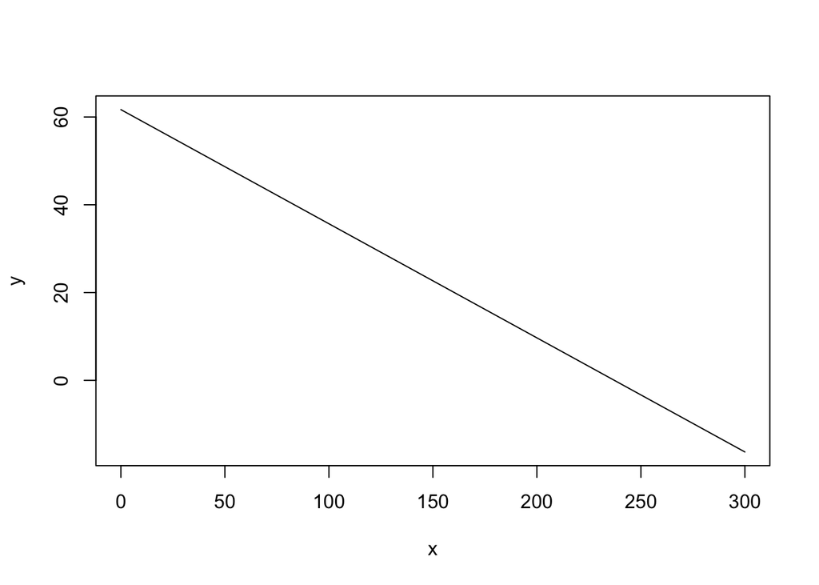

```r
#Sector D - Current Emissions = 300

quant_d <- seq(0,300,by=10)
curve_d_d <- function(q){
  (slope_d*(200-q)) + int_d
}
demand_d <- curve_d_d(quant_d)
curve(curve_d_d, from=0, to=300, xlab = "x", ylab = "y") #looks like it worked. Sweet.
```

```r
demand_d
```

```
##  [1]  61.6730127  59.0737374  56.4744621  53.8751868  51.2759114
##  [6]  48.6766361  46.0773608  43.4780854  40.8788101  38.2795348
## [11]  35.6802594  33.0809841  30.4817088  27.8824335  25.2831581
## [16]  22.6838828  20.0846075  17.4853321  14.8860568  12.2867815
## [21]   9.6875061   7.0882308   4.4889555   1.8896802  -0.7095952
## [26]  -3.3088705  -5.9081458  -8.5074212 -11.1066965 -13.7059718
## [31] -16.3052472
```

Sector A: $Price~of~Emissions = 0.5768419*(180-q) + -8.6444767$

- Willingness to Pay for First Unit = $95.2

Sector B: $Price~of~Emissions = 0.1987443*(200-q) + 9.3176977$

Sector C is willing to pay the most.

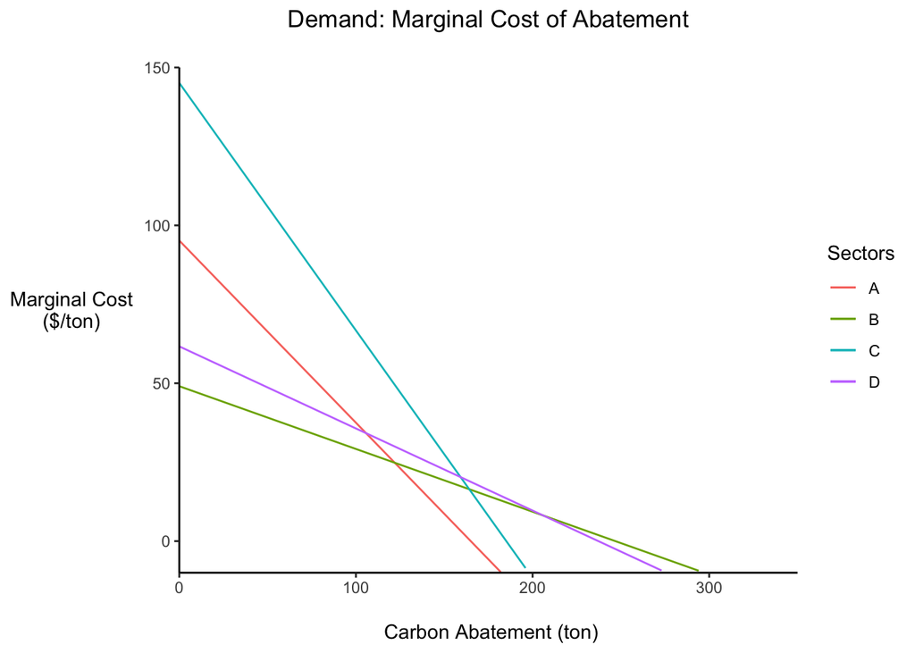

Free Market Qs Sector A: Q = 90 Sector B:Q = 100 Sector C:Q = 110 Sector D:Q = 150

### 3.

Now focus on country X (which contains sectors A, B, and C). Assume there are no “co-benefits” from carbon abatement (i.e. that there are no local pollutants that are affected by carbon abatement). Suppose to meet the Paris Accord commitments, country X needs to cut all carbon emissions in half. For each of the policy options listed below, derive:

#### a. Cap on carbon.

Each sector (A, B, and C) must cut its carbon emissions by 100 tons (thus reducing total emissions from 600 down to 300). Current carbon emissions in the sectors are: (A=180, B=200, C=220)

```r
#Sector A
costa_100 <- curve_a(100) #49 mc
areaa_100 <- integrate(curve_a, lower = 0, upper = 100)$value

#Sector B
costb_100 <- curve_b(100) #29.2 mc
areab_100 <- integrate(curve_b, lower = 0, upper = 100)$value

#Sector C
costc_100 <- curve_c(100) #66.7 mc
areac_100 <- integrate(curve_c, lower = 0, upper = 100)$value

#Sector D not part of this Q


#Total Cost:
tc_100 <- areaa_100 + areab_100 + areac_100 #6698.88
```

##### (1) the total cost of meeting the target in country X

$Total~Cost = 6698.882897$

##### (2) the cost (or benefit) to each sector

$Cost~to~A = 2020$

$Cost~to~B = 1925$

$Cost~to~C = 2754$

##### (3) the tax revenue generated.

Tax Revenue = 0

#### b. Tax on carbon.

To emit a ton of carbon in country X, you must pay a tax of $t. You will need to find the tax that accomplishes the desired reduction.

Emission functions:
$$Aggregate MC= 616.74 - Emissions / 8$$
$$Abatement_A = ( 95.75 - MC)/0.58$$
$$Abatement_B = (49.32-MC)/ 0.2$$
$$Abatement_C =(159.94-MC)/0.78$$
$$Abatement_D = (87.69 - MC)/0.26$$
See Table!

```
##                 Units abated     Cost       Tax
## Sector A            96.82328 1351.350  3833.476
## Sector B            48.63750 3918.915  1925.680
## Sector C           154.29167 1004.850  6108.793
## Total Country X    299.75244 6275.115 11867.949
```

```
##                 Units abated    Cost      Tax
## Sector A               96.82 1351.35  3833.48
## Sector B               48.64 3918.92  1925.68
## Sector C              154.29 1004.85  6108.79
## Total Country X       299.75 6275.12 11867.95
```

Taxation Option

|  | Units abated | Cost | Tax |
| --- | --- | --- | --- |
| Sector A | 96.8 | 1351.4 | 3833.5 |
| Sector B | 48.6 | 3918.9 | 1925.7 |
| Sector C | 154.3 | 1004.9 | 6108.8 |
| Total Country X | 299.8 | 6275.1 | 11867.9 |

3. Cap and trade. Each sector (A, B, C) is allocated carbon permits equal to their current emissions minus 100 (same as in (a) above), thus achieving the total reduction of 300. Then, these three sectors are allowed to trade with each other. You will need to derive the outcome of that trading.
1. the total cost of meeting the target in country X,
2. the cost (or benefit) to each sector
3. the tax revenue generated.

Equimarginal principle: firms will trade until the cost of abatement is the same between all 3 sectors. The goal is to abate 300 units of emissions, so the cost of abatement that meets the equimarginal principle is $39.59. Table below summarizes results.

```
##                 Units abated      Cost
## Sector A            96.82328  6562.803
## Sector B            48.63750  2162.241
## Sector C           154.29167 15393.101
## Total Country X    299.75244 24118.145
```

```
##                 Units abated    Cost
## Sector A                96.8  6562.8
## Sector B                48.6  2162.2
## Sector C               154.3 15393.1
## Total Country X        299.8 24118.1
```

Cap and Trade Option

|  | Units abated | Cost |
| --- | --- | --- |
| Sector A | 96.8 | 6562.8 |
| Sector B | 48.6 | 2162.2 |
| Sector C | 154.3 | 15393.1 |
| Total Country X | 299.8 | 24118.1 |

### 4.

Again, without any co-benefits, suppose that country Y (which only has one carbon-emitting sector, D) has no obligation to reduce its emissions. Country X asks country Y to enter the country X carbon market. Doing so would require country Y to put a cap on carbon emissions at its current level of emissions (300 tons), but would then allow country Y to sell carbon offsets to sectors A, B, or C.

##### Are there any incentives for country Y to enter country X’s carbon market and to thus place a voluntary cap on its emissions?

Sector Y might benefit from entering the international carbon market since their abatement costs are lower than Sectors A and C, so it could potentially be profitable.

##### Are there any incentives for country X to try to attract country Y into its market?

Sector B would benefit from country Y entering the international carbon market since their abatements costs are lower, so it could potentially be profitable.

### 5.

Now assume that every ton of carbon emissions creates 1 ton of local air pollution. Local air pollution causes economic damages (health, environmental, etc.), but only in the country in which it is emitted. Assume there are no local air pollution regulations in either country X or country Y.

#### a. In a carbon cap and trade market that only covers sectors in country X, how much local air pollution would you expect in country X? In country Y?

Both are emitting 300 tons, so both countires would also emit 300 tons of air polluntion.

#### b. If country Y enters the carbon market for country X (as in question 4 above), how much local pollution will there be in country X and country Y?

$Aggregate MC= 954.01 - Abatement / 11.85$

```r
MC<-(954.01-600) /11.85
MC #29.87
```

```
## [1] 29.87426
```

```r
300-222 #78
```

```
## [1] 78
```

```r
(87.69 - 39.59)/0.26
```

```
## [1] 185
```

```r
abatea<-(95.75 - MC)/0.58
abateb<-(49.32-MC)/ 0.2
abatec<-(159.94-MC)/0.78
abated<-(87.69 - MC)/0.26

totalabate<-sum(abatea, abateb, abatec, abated)
abate<-rbind(abatea, abateb, abatec, abated, totalabate)
abate
```

```
##                 [,1]
## abatea     113.57886
## abateb      97.22869
## abatec     166.75095
## abated     222.36822
## totalabate 599.92672
```

```r
costa<-(abatea*MC)+(abatea*(95.97-MC)*0.5)
costb<-(abateb*MC)+(abateb*(49.32-MC)*0.5)
costc<-(abatec*MC)+(abatec*(159.94-MC)*0.5)
costd<-(abated*MC)+(abated*(87.69-MC)*0.5)

totalcost<-sum(costa, costb, costc, costd)
cost<-rbind(costa, costb, costc, costd, totalcost)

part5<- cbind(abate, cost)
colnames(part5)=c("Units abated", "Cost")
row.names(part5)=c("Sector A", "Sector B", "Sector C", "Sector D","Total")
part5
```

```
##          Units abated      Cost
## Sector A    113.57886  7146.624
## Sector B     97.22869  3849.977
## Sector C    166.75095 15825.854
## Sector D    222.36822 13071.278
## Total       599.92672 39893.733
```

```r
round(part5,2)
```

```
##          Units abated     Cost
## Sector A       113.58  7146.62
## Sector B        97.23  3849.98
## Sector C       166.75 15825.85
## Sector D       222.37 13071.28
## Total          599.93 39893.73
```

```r
part5_df <- as.data.frame(part5)

kable(round(part5_df,1), caption = "International Cap and Trade") %>%
  kable_styling(bootstrap_options = "striped", full_width = F)
```

International Cap and Trade

|  | Units abated | Cost |
| --- | --- | --- |
| Sector A | 113.6 | 7146.6 |
| Sector B | 97.2 | 3850.0 |
| Sector C | 166.8 | 15825.9 |
| Sector D | 222.4 | 13071.3 |
| Total | 599.9 | 39893.7 |

#### c. What advice can you give country X and country Y about the desirability of allowing international trade of carbon emissions credits?

Not a great deal for country y, but it could be a good deal for country Y.